# Detecting Proper Bicep Curls

doctorpacket

07/21/2015

## Synopsis

The purpose of this machine learning algorithm is to detect whether bicep curls are performed with proper form.

## Experiment Setup

Readings from 4 sensors placed on the subject’s forearm, arm, belt, and dumbbell are obtained. Using these readings, the algorithm will try to predict whether the subject is performing bicep curls properly.

There are 6 subjects under this experiment. The bicep curls are performed in the following manner (classe):

- A - proper form
- B - throwing elbows to the front
- C - lifting the dumbbell halfway
- D - lowering the dumbbell halfway
- E - throwing hips to the front

## Preprocessing the Dataset

```r
tr <- read.csv('pml-training.csv', stringsAsFactors=F)
ts <- read.csv('pml-testing.csv', stringsAsFactors=F)
```

There are a total of 160 variables, some of which are not useful for our prediction. For example, aggregate results such as the average/variance/standard deviation are not present in the test set, and should be removed from the training process.

```r
dim(tr)
```

```
## [1] 19622   160
```

```r
apply(tr, MARGIN=2, FUN=function(col) {sum(is.na(col))})
```

```
##                        X                user_name     raw_timestamp_part_1
##                        0                        0                        0
##     raw_timestamp_part_2           cvtd_timestamp               new_window
##                        0                        0                        0
##               num_window                roll_belt               pitch_belt
##                        0                        0                        0
##                 yaw_belt         total_accel_belt       kurtosis_roll_belt
##                        0                        0                        0
##      kurtosis_picth_belt        kurtosis_yaw_belt       skewness_roll_belt
##                        0                        0                        0
##     skewness_roll_belt.1        skewness_yaw_belt            max_roll_belt
##                        0                        0                    19216
##           max_picth_belt             max_yaw_belt            min_roll_belt
##                    19216                        0                    19216
##           min_pitch_belt             min_yaw_belt      amplitude_roll_belt
##                    19216                        0                    19216
##     amplitude_pitch_belt       amplitude_yaw_belt     var_total_accel_belt
##                    19216                        0                    19216
##            avg_roll_belt         stddev_roll_belt            var_roll_belt
##                    19216                    19216                    19216
##           avg_pitch_belt        stddev_pitch_belt           var_pitch_belt
##                    19216                    19216                    19216
##             avg_yaw_belt          stddev_yaw_belt             var_yaw_belt
##                    19216                    19216                    19216
##             gyros_belt_x             gyros_belt_y             gyros_belt_z
##                        0                        0                        0
##             accel_belt_x             accel_belt_y             accel_belt_z
##                        0                        0                        0
##            magnet_belt_x            magnet_belt_y            magnet_belt_z
##                        0                        0                        0
##                 roll_arm                pitch_arm                  yaw_arm
##                        0                        0                        0
##          total_accel_arm            var_accel_arm             avg_roll_arm
##                        0                    19216                    19216
##          stddev_roll_arm             var_roll_arm            avg_pitch_arm
##                    19216                    19216                    19216
##         stddev_pitch_arm            var_pitch_arm              avg_yaw_arm
##                    19216                    19216                    19216
##           stddev_yaw_arm              var_yaw_arm              gyros_arm_x
##                    19216                    19216                        0
```

[output cut: 53 more lines]

```
##                        0                        0                    19216
##         avg_roll_forearm      stddev_roll_forearm         var_roll_forearm
##                    19216                    19216                    19216
##        avg_pitch_forearm     stddev_pitch_forearm        var_pitch_forearm
##                    19216                    19216                    19216
##          avg_yaw_forearm       stddev_yaw_forearm          var_yaw_forearm
##                    19216                    19216                    19216
##          gyros_forearm_x          gyros_forearm_y          gyros_forearm_z
##                        0                        0                        0
##          accel_forearm_x          accel_forearm_y          accel_forearm_z
##                        0                        0                        0
##         magnet_forearm_x         magnet_forearm_y         magnet_forearm_z
##                        0                        0                        0
##                   classe
##                        0
```

Looking at the test set, we also see that the data are disparate sample points in time, which greatly limits our ability to predict the classification as a function of time. Hence, we will remove the time-related columns.

```r
extractPredictors <- function(df) {
    ret <- df[,-grep('^(kurtosis|amplitude|skewness|min|max|avg|var|stddev)', colnames(df))]
    ret <- subset(ret, select=-c(cvtd_timestamp, new_window, num_window, raw_timestamp_part_1, raw_timestamp_part_2))
    ret
}

tr <- extractPredictors(tr)
tr$classe <- as.factor(tr$classe)
ts <- extractPredictors(ts)
```

## Data Analysis

Our first consideration is whether to apply a universal model to all test subjects. Due to differences in height, weight, body structure, and muscular strength, it is possible that each person would exhibit a unique pattern in sensor readings. We plot a number of readings across test subjects and classe to verify our intuition:

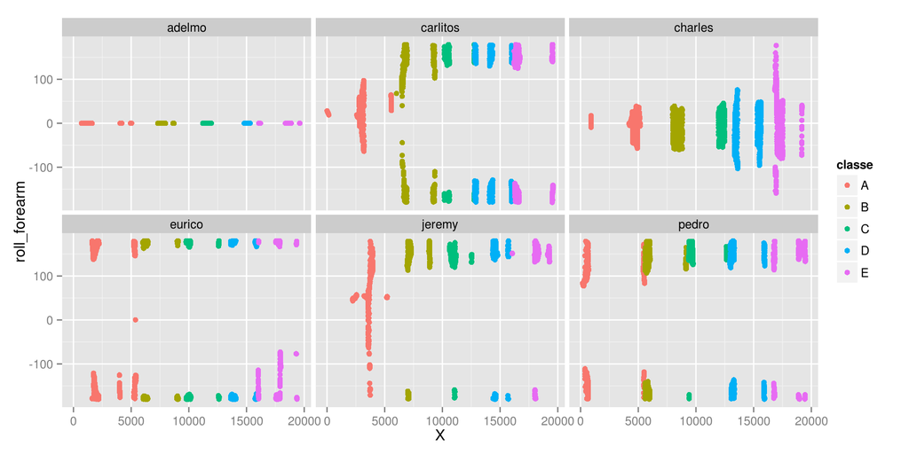

```r
library(ggplot2)

ggplot(tr, aes(x=X, y=roll_forearm, col=classe)) + geom_point() + facet_wrap(~user_name)
```

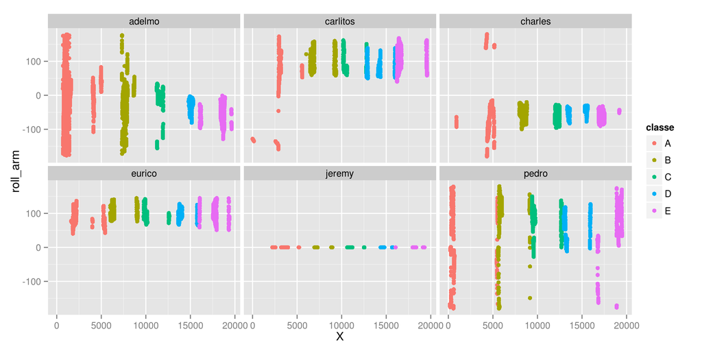

```r
ggplot(tr, aes(x=X, y=roll_arm, col=classe)) + geom_point() + facet_wrap(~user_name)
```

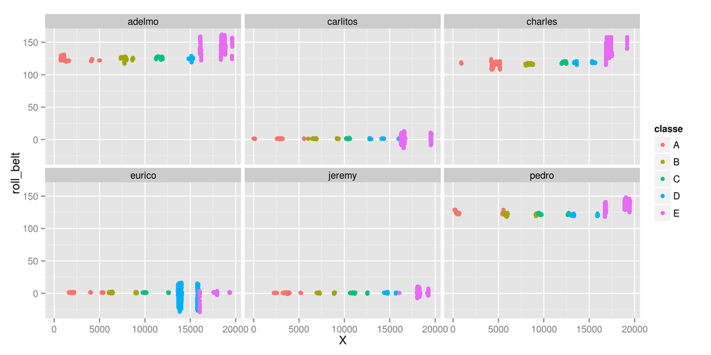

```r
ggplot(tr, aes(x=X, y=roll_belt, col=classe)) + geom_point() + facet_wrap(~user_name)
```

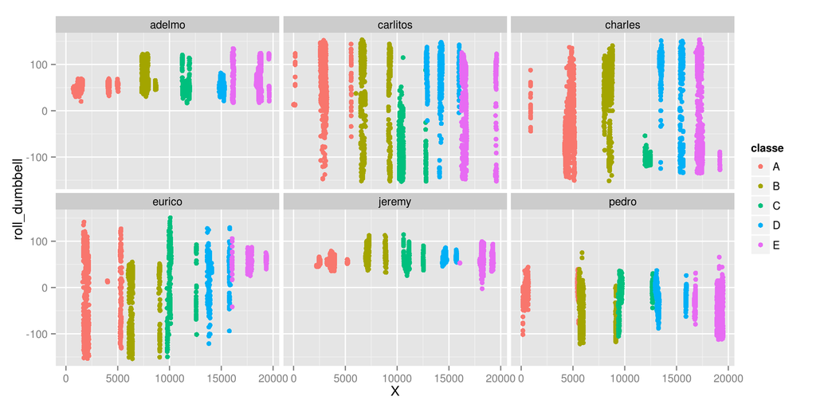

```r
ggplot(tr, aes(x=X, y=roll_dumbbell, col=classe)) + geom_point() + facet_wrap(~user_name)
```

From the plots, it seems that each test subject has a unique way of performing bicep curl, so a personalized model will be taliored for each person.

Also from the plots, we see that the sensors on Adelmo’s forearm and Jeremy’s arm seem to be malfunctioning:

```r
summary(tr[tr$user_name=='adelmo', c('roll_forearm','pitch_forearm','yaw_forearm')])
```

```
##   roll_forearm pitch_forearm  yaw_forearm
##  Min.   :0     Min.   :0     Min.   :0
##  1st Qu.:0     1st Qu.:0     1st Qu.:0
##  Median :0     Median :0     Median :0
##  Mean   :0     Mean   :0     Mean   :0
##  3rd Qu.:0     3rd Qu.:0     3rd Qu.:0
##  Max.   :0     Max.   :0     Max.   :0
```

```r
summary(tr[tr$user_name=='jeremy', c('roll_arm','pitch_arm','yaw_arm')])
```

```
##     roll_arm   pitch_arm    yaw_arm
##  Min.   :0   Min.   :0   Min.   :0
##  1st Qu.:0   1st Qu.:0   1st Qu.:0
##  Median :0   Median :0   Median :0
##  Mean   :0   Mean   :0   Mean   :0
##  3rd Qu.:0   3rd Qu.:0   3rd Qu.:0
##  Max.   :0   Max.   :0   Max.   :0
```

Hence, we will remove the forearm-related readings from Adelmo’s dataset, and arm-related readings from Jeremy’s dataset.

We will remove the user_name column (as we’re fitting one model per person), and the X column (which is simply the sample number):

```r
preprocessAdelmo <- function(df) {
    df <- subset(df, select=-c(X, user_name))
    df <- subset(df, select=-c(roll_forearm, pitch_forearm, yaw_forearm))
    df
}

preprocessJeremy <- function(df) {
    df <- subset(df, select=-c(X, user_name))
    df <- subset(df, select=-c(roll_arm, pitch_arm, yaw_arm))
    df
}

preprocess <- function(df) {
    df <- subset(df, select=-c(X, user_name))
    df
}

tr_adelmo <- preprocessAdelmo(tr[tr$user_name=='adelmo',])
ts_adelmo <- preprocessAdelmo(ts[ts$user_name=='adelmo',])

tr_carlitos <- preprocess(tr[tr$user_name=='carlitos',])
ts_carlitos <- preprocess(ts[ts$user_name=='carlitos',])

tr_charles <- preprocess(tr[tr$user_name=='charles',])
ts_charles <- preprocess(ts[ts$user_name=='charles',])

tr_eurico <- preprocess(tr[tr$user_name=='eurico',])
ts_eurico <- preprocess(ts[ts$user_name=='eurico',])

tr_jeremy <- preprocessJeremy(tr[tr$user_name=='jeremy',])
ts_jeremy <- preprocessJeremy(ts[ts$user_name=='jeremy',])

tr_pedro <- preprocess(tr[tr$user_name=='pedro',])
ts_pedro <- preprocess(ts[ts$user_name=='pedro',])
```

## Training and Predicting

We will try three machine learning algorithms suited for classification problems with discrete outcomes: rf, gbm, and lda.

We create a helper function that splits the data into training and test set for cross-validation, and prints out the confusion matrix with the expected out-of-sample error:

```r
library(caret)
library(doParallel)
registerDoParallel(cores=4)

modelAndPredict <- function(df, m, ...) {
    set.seed(1234)
    inTrain = createDataPartition(df$classe, p=3/4)[[1]]
    trainset <- df[inTrain,]
    testset <- df[-inTrain,]
    model <- train(classe ~ ., data=trainset, method=m, ...)
    pred <- predict(model, testset)
    print(confusionMatrix(pred, testset$classe))
    model
}
```

We will test the performance of these 3 algorithms using Adelmo’s dataset:

```r
modrf_adelmo <- modelAndPredict(tr_adelmo, 'rf')
```

```
## Confusion Matrix and Statistics
##
##           Reference
## Prediction   A   B   C   D   E
##          A 291   2   0   0   0
##          B   0 191   0   0   0
##          C   0   1 186   3   0
##          D   0   0   1 125   0
##          E   0   0   0   0 171
##
## Overall Statistics
##
##                Accuracy : 0.9928
##                  95% CI : (0.9852, 0.9971)
##     No Information Rate : 0.2997
##     P-Value [Acc > NIR] : < 2.2e-16
##
##                   Kappa : 0.9908
##  Mcnemar's Test P-Value : NA
##
## Statistics by Class:
##
##                      Class: A Class: B Class: C Class: D Class: E
## Sensitivity            1.0000   0.9845   0.9947   0.9766   1.0000
## Specificity            0.9971   1.0000   0.9949   0.9988   1.0000
## Pos Pred Value         0.9932   1.0000   0.9789   0.9921   1.0000
## Neg Pred Value         1.0000   0.9962   0.9987   0.9964   1.0000
## Prevalence             0.2997   0.1998   0.1926   0.1318   0.1761
## Detection Rate         0.2997   0.1967   0.1916   0.1287   0.1761
## Detection Prevalence   0.3018   0.1967   0.1957   0.1298   0.1761
## Balanced Accuracy      0.9985   0.9923   0.9948   0.9877   1.0000
```

```r
modgbm_adelmo <- modelAndPredict(tr_adelmo, 'gbm')
```

```
##
## Confusion Matrix and Statistics
##
##           Reference
## Prediction   A   B   C   D   E
##          A 291   2   0   0   0
##          B   0 191   2   0   0
##          C   0   1 185   1   0
##          D   0   0   0 127   0
##          E   0   0   0   0 171
##
## Overall Statistics
##
##                Accuracy : 0.9938
##                  95% CI : (0.9866, 0.9977)
##     No Information Rate : 0.2997
##     P-Value [Acc > NIR] : < 2.2e-16
##
##                   Kappa : 0.9921
##  Mcnemar's Test P-Value : NA
##
## Statistics by Class:
##
##                      Class: A Class: B Class: C Class: D Class: E
## Sensitivity            1.0000   0.9845   0.9893   0.9922   1.0000
## Specificity            0.9971   0.9974   0.9974   1.0000   1.0000
## Pos Pred Value         0.9932   0.9896   0.9893   1.0000   1.0000
## Neg Pred Value         1.0000   0.9961   0.9974   0.9988   1.0000
## Prevalence             0.2997   0.1998   0.1926   0.1318   0.1761
## Detection Rate         0.2997   0.1967   0.1905   0.1308   0.1761
## Detection Prevalence   0.3018   0.1988   0.1926   0.1308   0.1761
## Balanced Accuracy      0.9985   0.9910   0.9934   0.9961   1.0000
```

```r
modlda_adelmo <- modelAndPredict(tr_adelmo, 'lda')
```

```
## Confusion Matrix and Statistics
##
##           Reference
## Prediction   A   B   C   D   E
##          A 279  27   1   1   0
##          B   0 154  11   8   4
##          C  11  11 160  28   1
##          D   1   2  15  91   0
##          E   0   0   0   0 166
##
## Overall Statistics
##
##                Accuracy : 0.8754
##                  95% CI : (0.853, 0.8955)
##     No Information Rate : 0.2997
##     P-Value [Acc > NIR] : < 2.2e-16
##
##                   Kappa : 0.8406
##  Mcnemar's Test P-Value : NA
##
## Statistics by Class:
##
##                      Class: A Class: B Class: C Class: D Class: E
## Sensitivity            0.9588   0.7938   0.8556  0.71094   0.9708
## Specificity            0.9574   0.9704   0.9349  0.97865   1.0000
## Pos Pred Value         0.9058   0.8701   0.7583  0.83486   1.0000
## Neg Pred Value         0.9819   0.9496   0.9645  0.95708   0.9938
## Prevalence             0.2997   0.1998   0.1926  0.13182   0.1761
## Detection Rate         0.2873   0.1586   0.1648  0.09372   0.1710
## Detection Prevalence   0.3172   0.1823   0.2173  0.11226   0.1710
## Balanced Accuracy      0.9581   0.8821   0.8953  0.84479   0.9854
```

From the output, it seems that gbm has a much higher accuracy than lda, and a slightly higher accuracy than rf. Hence, we will apply gbm to predict the results for the remaining test subjects:

```r
modgbm_carlitos <- modelAndPredict(tr_carlitos, 'gbm')
```

```
##
## Confusion Matrix and Statistics
##
##           Reference
## Prediction   A   B   C   D   E
##          A 208   0   0   0   0
##          B   0 172   0   0   2
##          C   0   0 123   0   2
##          D   0   0   0 121   2
##          E   0   0   0   0 146
##
## Overall Statistics
##
##                Accuracy : 0.9923
##                  95% CI : (0.9832, 0.9972)
##     No Information Rate : 0.268
##     P-Value [Acc > NIR] : < 2.2e-16
##
##                   Kappa : 0.9902
##  Mcnemar's Test P-Value : NA
##
## Statistics by Class:
##
##                      Class: A Class: B Class: C Class: D Class: E
## Sensitivity             1.000   1.0000   1.0000   1.0000   0.9605
## Specificity             1.000   0.9967   0.9969   0.9969   1.0000
## Pos Pred Value          1.000   0.9885   0.9840   0.9837   1.0000
## Neg Pred Value          1.000   1.0000   1.0000   1.0000   0.9905
## Prevalence              0.268   0.2216   0.1585   0.1559   0.1959
## Detection Rate          0.268   0.2216   0.1585   0.1559   0.1881
## Detection Prevalence    0.268   0.2242   0.1611   0.1585   0.1881
## Balanced Accuracy       1.000   0.9983   0.9985   0.9985   0.9803
```

```r
modgbm_charles <- modelAndPredict(tr_charles, 'gbm')
```

```
##
## Confusion Matrix and Statistics
##
##           Reference
## Prediction   A   B   C   D   E
##          A 224   0   0   0   0
##          B   0 186   0   0   0
##          C   0   0 134   0   0
##          D   0   0   0 160   0
##          E   0   0   0   0 177
##
## Overall Statistics
##
##                Accuracy : 1
##                  95% CI : (0.9958, 1)
##     No Information Rate : 0.2543
##     P-Value [Acc > NIR] : < 2.2e-16
##
##                   Kappa : 1
##  Mcnemar's Test P-Value : NA
##
## Statistics by Class:
##
##                      Class: A Class: B Class: C Class: D Class: E
## Sensitivity            1.0000   1.0000   1.0000   1.0000   1.0000
## Specificity            1.0000   1.0000   1.0000   1.0000   1.0000
## Pos Pred Value         1.0000   1.0000   1.0000   1.0000   1.0000
## Neg Pred Value         1.0000   1.0000   1.0000   1.0000   1.0000
## Prevalence             0.2543   0.2111   0.1521   0.1816   0.2009
## Detection Rate         0.2543   0.2111   0.1521   0.1816   0.2009
## Detection Prevalence   0.2543   0.2111   0.1521   0.1816   0.2009
## Balanced Accuracy      1.0000   1.0000   1.0000   1.0000   1.0000
```

```r
modgbm_eurico <- modelAndPredict(tr_eurico, 'gbm')
```

```
##
## Confusion Matrix and Statistics
##
##           Reference
## Prediction   A   B   C   D   E
##          A 212   0   0   0   0
##          B   4 148   2   0   0
##          C   0   0 120   1   0
##          D   0   0   0 144   0
##          E   0   0   0   0 135
##
## Overall Statistics
##
##                Accuracy : 0.9909
##                  95% CI : (0.9813, 0.9963)
##     No Information Rate : 0.282
##     P-Value [Acc > NIR] : < 2.2e-16
##
##                   Kappa : 0.9885
##  Mcnemar's Test P-Value : NA
##
## Statistics by Class:
##
##                      Class: A Class: B Class: C Class: D Class: E
## Sensitivity            0.9815   1.0000   0.9836   0.9931   1.0000
## Specificity            1.0000   0.9903   0.9984   1.0000   1.0000
## Pos Pred Value         1.0000   0.9610   0.9917   1.0000   1.0000
## Neg Pred Value         0.9928   1.0000   0.9969   0.9984   1.0000
## Prevalence             0.2820   0.1932   0.1593   0.1893   0.1762
## Detection Rate         0.2768   0.1932   0.1567   0.1880   0.1762
## Detection Prevalence   0.2768   0.2010   0.1580   0.1880   0.1762
## Balanced Accuracy      0.9907   0.9951   0.9910   0.9966   1.0000
```

```r
modgbm_jeremy <- modelAndPredict(tr_jeremy, 'gbm')
```

```
##
## Confusion Matrix and Statistics
##
##           Reference
## Prediction   A   B   C   D   E
##          A 292   0   0   0   0
##          B   2 122   0   0   0
##          C   0   0 163   0   0
##          D   0   0   0 127   0
##          E   0   0   0   3 140
##
## Overall Statistics
##
##                Accuracy : 0.9941
##                  95% CI : (0.9863, 0.9981)
##     No Information Rate : 0.3463
##     P-Value [Acc > NIR] : < 2.2e-16
##
##                   Kappa : 0.9924
##  Mcnemar's Test P-Value : NA
##
## Statistics by Class:
##
##                      Class: A Class: B Class: C Class: D Class: E
## Sensitivity            0.9932   1.0000    1.000   0.9769   1.0000
## Specificity            1.0000   0.9972    1.000   1.0000   0.9958
## Pos Pred Value         1.0000   0.9839    1.000   1.0000   0.9790
## Neg Pred Value         0.9964   1.0000    1.000   0.9958   1.0000
## Prevalence             0.3463   0.1437    0.192   0.1531   0.1649
## Detection Rate         0.3439   0.1437    0.192   0.1496   0.1649
## Detection Prevalence   0.3439   0.1461    0.192   0.1496   0.1684
## Balanced Accuracy      0.9966   0.9986    1.000   0.9885   0.9979
```

```r
modgbm_pedro <- modelAndPredict(tr_pedro, 'gbm')
```

```
##
## Confusion Matrix and Statistics
##
##           Reference
## Prediction   A   B   C   D   E
##          A 159   1   0   0   0
##          B   0 124   0   0   0
##          C   0   1 124   2   0
##          D   1   0   0 115   0
##          E   0   0   0   0 124
##
## Overall Statistics
##
##                Accuracy : 0.9923
##                  95% CI : (0.9822, 0.9975)
##     No Information Rate : 0.2458
##     P-Value [Acc > NIR] : < 2.2e-16
##
##                   Kappa : 0.9904
##  Mcnemar's Test P-Value : NA
##
## Statistics by Class:
##
##                      Class: A Class: B Class: C Class: D Class: E
## Sensitivity            0.9938   0.9841   1.0000   0.9829   1.0000
## Specificity            0.9980   1.0000   0.9943   0.9981   1.0000
## Pos Pred Value         0.9937   1.0000   0.9764   0.9914   1.0000
## Neg Pred Value         0.9980   0.9962   1.0000   0.9963   1.0000
## Prevalence             0.2458   0.1935   0.1905   0.1797   0.1905
## Detection Rate         0.2442   0.1905   0.1905   0.1767   0.1905
## Detection Prevalence   0.2458   0.1905   0.1951   0.1782   0.1905
## Balanced Accuracy      0.9959   0.9921   0.9972   0.9905   1.0000
```

In all six models, the out-of-sample errors is expected to be lower than 2%! (lower bound of 95% CI accuracy is higher than 98% across all six models)

Finally, we write the output of our predictions:

```r
for(i in 1:nrow(ts)) {
    # setup default factor variable
    p <- tr$classe[1]

    u <- ts$user_name[i]
    if(u=='adelmo') {
        p <- predict(modgbm_adelmo, ts[i,])
    }
    else if(u=='carlitos') {
        p <- predict(modgbm_carlitos, ts[i,])
    }
    else if(u=='charles') {
        p <- predict(modgbm_charles, ts[i,])
    }
    else if(u=='eurico') {
        p <- predict(modgbm_eurico, ts[i,])
    }
    else if(u=='jeremy') {
        p <- predict(modgbm_jeremy, ts[i,])
    }
    else if(u=='pedro') {
        p <- predict(modgbm_pedro, ts[i,])
    }

    filename = paste0("problem_id_",i,".txt")
    write(as.character(p), file=filename)
}
```